# ASS4

Tristan LaRose

2023-11-27

# 10/10

# Question 1

```r
birds <- read.csv("NZBIRDS.csv")
head(birds)
```

```
##   Species          Name Extinct Habitat Nest.Site Nest.Density Diet Flight
## 1  Grebes  P. cristatus      No       A         G            L    F    Yes
## 2  Grebes P. rufopectus      No       A         G            L    F    Yes
## 3 Petrels      P. gavia     Yes       A        GC            H    F    Yes
## 4 Petrels    P. huttoni  Absent       A        GC            H    F    Yes
## 5 Petrels   P. spelaeus  Absent       A        GC            H    F    Yes
## 6 Petrels  P. assimilis     Yes       A        GC            H    F    Yes
##   Body.Mass Egg.Length
## 1      1100         57
## 2       250         43
## 3       300         57
## 4       350         60
## 5       250         55
## 6       200         54
```

## a

```r
n <- length(birds$Body.Mass)

set.seed(5)

sam <- runif(35,1,n-1)
```

## b

#### mean

```r
bodymass <- birds$Body.Mass[sam]
mean(bodymass)
```

```
## [1] 7798.571
```

#### sd

```r
sd(bodymass)
```

```
## [1] 20622.18
```

#### ci

```r
MATH4753TRISTAN2023::myci(bodymass)
```

```
## [1]   714.6039 14882.5390
## attr(,"conf.level")
## [1] 0.95
```

## c

With 95% confidence we can say that the mean value of body mass for the birds is between 714.6039 and 14882.5390.

## d

It is very likely to contain $\mu$ because 95% percent of the intervals created will contain the true mean of the body mass value of the birds.

## e

#### mean

```r
set.seed(5)
sam1 <- runif(35,1,n-1)
egglength <- birds$Egg.Length[sam1]
mean(egglength)
```

```
## [1] 68.14286
```

#### sd

```r
sd(egglength)
```

```
## [1] 43.84675
```

#### ci

```r
MATH4753TRISTAN2023::myci(egglength)
```

```
## [1] 53.08097 83.20474
## attr(,"conf.level")
## [1] 0.95
```

## f

```r
n1 = 38 # total extinct
n2 = 78 # total not extinct

p1hat = 21 / n1
q1hat = 1 - p1hat
p2hat = 7 / n2
q2hat = 1 - p2hat

mp = c(-1,1)
ci <- (p1hat - p2hat) + mp * qnorm(1-.05/2,0,1)*sqrt((p1hat*q1hat/n1) + (p2hat*q2hat/n2))
ci
```

```
## [1] 0.2925475 0.6332285
```

## g

Yes, it does support this theory.

# Question 2

## a

```r
s1 <- rnorm(100, mean = 1312, sd = 422)
s2<- rnorm(47, mean = 1352, sd = 271)

t.test(s1,s2, conf.level = .90)
```

```
##
##  Welch Two Sample t-test
##
## data:  s1 and s2
## t = 0.79476, df = 126, p-value = 0.4282
## alternative hypothesis: true difference in means is not equal to 0
## 90 percent confidence interval:
##  -51.82906 147.37177
## sample estimates:
## mean of x mean of y
##  1318.355  1270.584
```

## b

```r
s1 <- rnorm(100, mean = 1312, sd = 422)
s2<- rnorm(47, mean = 1352, sd = 271)

var.test(s1,s2, conf.level = .90)
```

```
##
##  F test to compare two variances
##
## data:  s1 and s2
## F = 3.9593, num df = 99, denom df = 46, p-value = 1.192e-06
## alternative hypothesis: true ratio of variances is not equal to 1
## 90 percent confidence interval:
##  2.557382 5.907018
## sample estimates:
## ratio of variances
##           3.959279
```

# Question 3

## a

$Z=(Y-0)/\sigma)$ Has a normal distribution. Thus, $Z^2=(Y^2)/\sigma^2)$ Which by theorem 6.11 is a $\chi^2$ distribution with 1 degree of freedom.

## b

$P(\chi_{1−α/2}\le y^2/\sigma^2\le\chi_{α/2})=1−\alpha=P(y^2/\chi_{α/2}\le\sigma^2\le y^2/\chi_{1−α/2})$

# Question 4

```r
Rough <- read.csv("ROUGHPIPE.csv")
rough <-Rough$ROUGH
```

## a

The null hypothesis is that $\mu = 2$ and the alternative hypothesis is that $\mu \neq2$

## b

T: -1.02 and the P-value:0.322

## c

```r
df=length(rough)-1
alpha=0.05
lowtq=qt(alpha/2,df)
lowtq
```

```
## [1] -2.093024
```

```r
uptq=qt(1-alpha/2,df)
uptq
```

```
## [1] 2.093024
```

The rejection region is below −2.093024 and above 2.093024.

## d

Since the pvalue is greater than alpha, we accept the null hypotehsis

## e

# Question 5

```r
lake <- read.csv("WISCLAKES.csv")
oxy <- lake$DOC
```

## a

```r
t.test(oxy, alpha=0.1, mu=15)
```

```
##
##  One Sample t-test
##
## data:  oxy
## t = -0.18668, df = 24, p-value = 0.8535
## alternative hypothesis: true mean is not equal to 15
## 95 percent confidence interval:
##   9.164852 19.867148
## sample estimates:
## mean of x
##    14.516
```

Based on the cofidence interval, it is likely representative.

## b

```r
t.test(oxy, alpha=0.1, mu=14)
```

```
##
##  One Sample t-test
##
## data:  oxy
## t = 0.19902, df = 24, p-value = 0.8439
## alternative hypothesis: true mean is not equal to 14
## 95 percent confidence interval:
##   9.164852 19.867148
## sample estimates:
## mean of x
##    14.516
```

p-value = 0.8439

# Question 6

```r
data <- read.csv("ORCHARD.csv")
foggy <- data[data$CONDITION == "FOG",]
cloudyClear <- data[data$CONDITION != "FOG",]

t.test(data$CONDITION == "FOG",data$CONDITION != "FOG", mu= 0, conf.level = .95)
```

```
##
##  Welch Two Sample t-test
##
## data:  data$CONDITION == "FOG" and data$CONDITION != "FOG"
## t = 2.0412, df = 24, p-value = 0.05237
## alternative hypothesis: true difference in means is not equal to 0
## 95 percent confidence interval:
##  -0.004269104  0.773499874
## sample estimates:
## mean of x mean of y
## 0.6923077 0.3076923
```

We see the pvalue is > than alpha, thus we accept $H_0:\mu_1-\mu_2 = 0$

# Question 7

## a

```r
turbine <- read.csv("GASTURBINE.csv")

traditional <- turbine[turbine$ENGINE == "Traditional",]


aeroder <- turbine[turbine$ENGINE == "Aeroderiv",]

var.test(traditional$HEATRATE, aeroder$HEATRATE,conf.level = .95, var.equal=T)
```

```
##
##  F test to compare two variances
##
## data:  traditional$HEATRATE and aeroder$HEATRATE
## F = 0.23272, num df = 38, denom df = 6, p-value = 0.004234
## alternative hypothesis: true ratio of variances is not equal to 1
## 95 percent confidence interval:
##  0.04635082 0.64308536
## sample estimates:
## ratio of variances
##          0.2327207
```

## b

```r
advanced <-  turbine[turbine$ENGINE == "Advanced",]

var.test(advanced$HEATRATE, aeroder$HEATRATE,conf.level = .95, var.equal=T)
```

```
##
##  F test to compare two variances
##
## data:  advanced$HEATRATE and aeroder$HEATRATE
## F = 0.057974, num df = 20, denom df = 6, p-value = 1.192e-06
## alternative hypothesis: true ratio of variances is not equal to 1
## 95 percent confidence interval:
##  0.0112170 0.1813622
## sample estimates:
## ratio of variances
##         0.05797393
```

# Question 8

```r
ants <- read.csv("GOBIANTS.csv")
```

## a

Null: $\sigma^2_1/\sigma^2_2=1$

Alternative: $\sigma^2_1/\sigma^2_2≠1$

## b

### F-Statistic

```r
dry <- ants[1:5,]
gobi <- ants[6:10,]

vdry <- dry$AntSpecies
vgobi <- gobi$AntSpecies

var.test(vdry,vgobi,conf.level = 0.95)
```

```
##
##  F test to compare two variances
##
## data:  vdry and vgobi
## F = 1.1456, num df = 4, denom df = 4, p-value = 0.8984
## alternative hypothesis: true ratio of variances is not equal to 1
## 95 percent confidence interval:
##   0.1192767 11.0029184
## sample estimates:
## ratio of variances
##           1.145597
```

## c

The rejection region is less than 0.1192767 and greater than 11.0029184 for a 95% confidence interval.

## d

p-value = 0.8984

## e

We accept the null hypothesis that the variances of ant species at the two different sites are the same.

## f

The populations must be normally distributed and the samples must be independent and random for an f-test to be valid.

# Question 9

The NULL and alternative hypotheses are: $H_0: \mu_d = 0$ and $H_1: \mu_d \neq 0$

We will assume equal variances.

```r
data<- read.csv("THRUPUT.csv")

t.test(data$HUMAN, data$AUTO, mu=0, paired = T)
```

```
##
##  Paired t-test
##
## data:  data$HUMAN and data$AUTO
## t = -2.629, df = 7, p-value = 0.03396
## alternative hypothesis: true mean difference is not equal to 0
## 95 percent confidence interval:
##  -61.850346  -3.274654
## sample estimates:
## mean difference
##        -32.5625
```

We see that the pvalue is < than alpha (.05), therefore we must reject the null hypothesis.

# Question 10

## sample function

```r
set.seed(35) # This will give everyone the same sample
sam=round(rnorm(30,mean=20,sd=3),3)
```

### bootstrap function

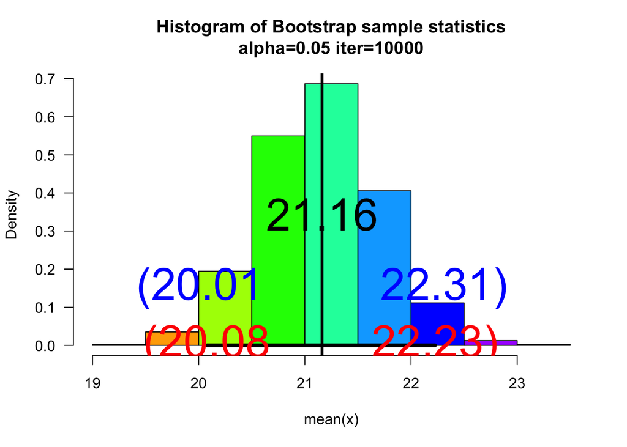

```
## $ci
##     2.5%    97.5%
## 20.07910 22.22545
##
## $fun
## [1] "mean"
##
## $x
##  [1] 23.195 20.399 19.898 19.865 30.014 18.821 21.232 18.313 23.574 21.047
## [11] 21.535 21.336 17.695 18.497 14.274 14.664 22.593 18.963 25.515 25.019
## [21] 22.053 22.871 23.006 23.829 19.038 21.735 21.461 21.659 21.703 21.049
##
## $t
## function (x)
## UseMethod("t")
## <bytecode: 0x7fdeb04c5960>
## <environment: namespace:base>
```

```r
set.seed(35); sam <- round(rnorm(30,mean=20, sd=3),3)

myboot<-function(iter=10000,x,fun="mean",alpha=0.05,...){  #Notice where the ... is repeated in the code
n=length(x)   #sample size


df=n-1
s=sd(x)
ybar=mean(x)
t_quant=qt(1-alpha/2,df)
L=ybar-(t_quant*s)/(sqrt(n))
U=ybar+(t_quant*s)/(sqrt(n))

y=sample(x,n*iter,replace=TRUE)
rs.mat=matrix(y,nr=n,nc=iter,byrow=TRUE)
xstat=apply(rs.mat,2,fun) # xstat is a vector and will have iter values in it
ci=quantile(xstat,c(alpha/2,1-alpha/2))# Nice way to form a confidence interval
# A histogram follows
# The object para will contain the parameters used to make the histogram
para=hist(xstat,breaks=9,freq=FALSE,las=1,
main=paste("Histogram of Bootstrap sample statistics","\n","alpha=",alpha," iter=",iter,sep=""),
...)
para

#mat will be a matrix that contains the data, this is done so that I can use apply()
mat=matrix(x,nr=length(x),nc=1,byrow=TRUE)

#pte is the point estimate
#This uses whatever fun is
pte=apply(mat,2,fun)
abline(v=pte,lwd=3,col="Black")# Vertical line
segments(ci[1],0,ci[2],0,lwd=4)      #Make the segment for the ci
text(ci[1],0,paste("(",round(ci[1],2),sep=""),col="Red",cex=3)
text(ci[2],0,paste(round(ci[2],2),")",sep=""),col="Red",cex=3)
text(L,0.15,paste("(",round(L,2),sep=""),col="Blue",cex=3)
text(U,0.15,paste(round(U,2),")",sep=""),col="Blue",cex=3)

# plot the point estimate 1/2 way up the density
text(pte,max(para$density)/2,round(pte,2),cex=3)

return(list(ci=ci,fun=fun,x=x, t=t))# Some output to use if necessary
}

myboot(10000,x=sam,fun="mean",alpha=0.05,xlab="mean(x)",col=rainbow(9))
```